# Drug-Combination BOIN: Exploration and Exploitation

Phase I dose-finding coding exercise

October 20, 2026

# 1 Purpose and question

This exercise studies a two-drug phase I trial on a $4\times4$ grid of combinations $A_jB_k$. The maximum sample size is fixed at 48 patients, enrolled in cohorts of 3. The target dose-limiting toxicity (DLT) probability is

$$\phi=0.25.$$

The experiment compares candidate sets containing up to 2, 3, or 4 adjacent combinations whenever the design must escalate or de-escalate. It also includes a local parallel strategy that sends one new cohort to each of two adjacent combinations. The scientific question is whether giving the algorithm more choices or parallel information improves exploration of the two-dimensional grid enough to offset reduced adaptivity and possible exposure to poorly understood combinations.

The two-candidate rule is standard combination BOIN. The three- and four-candidate and parallel rules are deliberately experimental extensions for this coding exercise; they are **not** published BOIN recommendations and would need a much larger validation study before protocol use.

## 1.1 Editable simulation settings

These are the only values that normally need to be changed for a quick rerun.

```r
target <- 0.25
toxic_threshold <- 0.33
candidate_sizes <- 2:4
n_sim <- 1000L
n_patients <- 48L
cohort_size <- 3L
parallel_cohorts_per_combo <- 1L
simulation_seed <- 20261017L
sample_size_grid <- seq(48L, 90L, by = 6L)
n_sim_sample_size <- 1000L
detected_cores <- suppressWarnings(parallel::detectCores(logical = TRUE))
if (is.na(detected_cores)) detected_cores <- 8L
parallel_cores <- max(1L, min(8L, detected_cores))

data.frame(
  setting = c("Target phi", "Clearly toxic threshold",
              "Replicates per scenario-design cell",
              "Maximum sample size", "Cohort size",
              "Parallel cohorts per candidate", "Random seed",
              "Sample-size sensitivity grid",
              "Sensitivity replicates per cell", "Parallel workers"),
  value = c(target, toxic_threshold, n_sim, n_patients, cohort_size,
            parallel_cohorts_per_combo, simulation_seed,
            paste(sample_size_grid, collapse = ", "),
            n_sim_sample_size, parallel_cores)
) |>
  knitr::kable(row.names = FALSE)
```

| setting | value |
| --- | --- |
| Target phi | 0.25 |
| Clearly toxic threshold | 0.33 |
| Replicates per scenario-design cell | 1000 |
| Maximum sample size | 48 |
| Cohort size | 3 |
| Parallel cohorts per candidate | 1 |
| Random seed | 20261017 |
| Sample-size sensitivity grid | 48, 54, 60, 66, 72, 78, 84, 90 |
| Sensitivity replicates per cell | 1000 |
| Parallel workers | 8 |

# 2 Four interaction scenarios

The four matrices below are constructed teaching scenarios informed by the interaction patterns studied in the combination-dose-finding literature; they are not copied from one publication. All four preserve coordinate-wise monotonicity. “Synergy” and “antagonism” here refer to *toxicity interaction* relative to a common additive reference surface, not therapeutic efficacy.

1. **Global synergy:** joint toxicity rises faster than the additive reference across most of the grid.
2. **Global antagonism:** joint toxicity rises more slowly across most of the grid, producing a broad MTD contour.
3. **Low-dose synergy / high-dose antagonism:** toxicity is relatively amplified at the lower grid and attenuated at the upper grid.
4. **Low-dose antagonism / high-dose synergy:** the reverse crossover pattern; upper combinations become toxic quickly.

```r
scenarios <- make_combo_scenarios()
additive_reference <- make_additive_reference()

scenario_table <- do.call(rbind, lapply(names(scenarios), function(name) {
  truth <- scenarios[[name]]
  mtd <- true_combo_mtds(truth, target)
  data.frame(
    scenario = name,
    minimum_DLT = min(truth),
    maximum_DLT = max(truth),
    true_MTD_combinations = paste(
      paste0("A", mtd[, 1L], "B", mtd[, 2L]), collapse = ", "
    ),
    true_MTD_probabilities = paste(
      formatC(truth[mtd], format = "f", digits = 2L), collapse = ", "
    )
  )
}))
knitr::kable(scenario_table, digits = 2, row.names = FALSE)
```

| scenario | minimum_DLT | maximum_DLT | true_MTD_combinations | true_MTD_probabilities |
| --- | --- | --- | --- | --- |
| Global synergy | 0.04 | 0.70 | A4B1, A3B2, A2B3, A1B4 | 0.24, 0.26, 0.26, 0.24 |
| Global antagonism | 0.04 | 0.35 | A4B2, A3B3, A4B3, A2B4, A3B4 | 0.22, 0.22, 0.28, 0.22, 0.28 |
| Low synergy / high antagonism | 0.06 | 0.44 | A3B2, A2B3 | 0.24, 0.24 |
| Low antagonism / high synergy | 0.02 | 0.68 | A4B2, A2B4 | 0.27, 0.27 |

In each plot:

- Each grid cell prints its true DLT probability.
- The light teal line is the interpolated 25% toxicity contour.
- Large pale circles mark the discrete true MTD combinations closest to 25%.

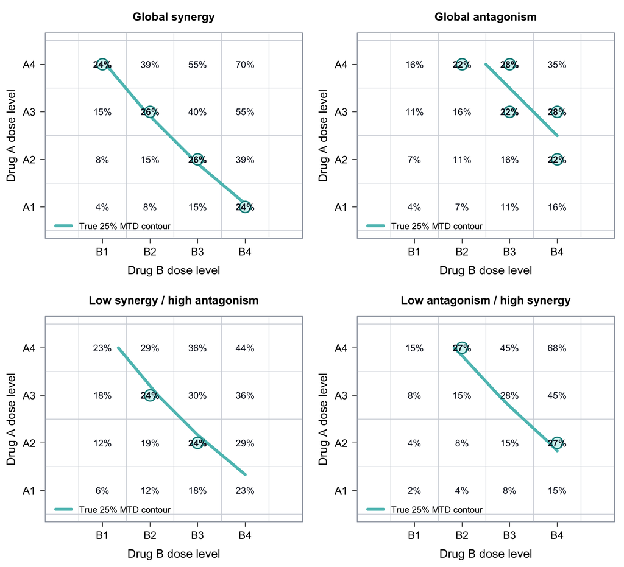

```r
old_par <- par(mfrow = c(2, 2), mar = c(4.8, 4.8, 3.5, 1))
for (name in names(scenarios)) {
  plot_combo_scenario_grid(
    probability = scenarios[[name]],
    target = target,
    main = name
  )
}
```

```r
par(old_par)
```

# 3 BOIN decision rule

The usual BOIN defaults are $\phi_1=0.6\phi=0.15$ for an under-toxic dose and $\phi_2=1.4\phi=0.35$ for an over-toxic dose. The optimal boundaries are

$$\lambda_e=
\frac{\log\{(1-\phi_1)/(1-\phi)\}}
{\log\{\phi(1-\phi_1)/[\phi_1(1-\phi)]\}},
\qquad
\lambda_d=
\frac{\log\{(1-\phi)/(1-\phi_2)\}}
{\log\{\phi_2(1-\phi)/[\phi(1-\phi_2)]\}}.$$

```r
boundaries <- boin_boundaries(target)
data.frame(
  target = target,
  phi1 = 0.6 * target,
  phi2 = 1.4 * target,
  lambda_e = unname(boundaries["escalate"]),
  lambda_d = unname(boundaries["deescalate"])
) |>
  knitr::kable(digits = 4, row.names = FALSE)
```

| target | phi1 | phi2 | lambda_e | lambda_d |
| --- | --- | --- | --- | --- |
| 0.25 | 0.15 | 0.35 | 0.1968 | 0.2984 |

At the current combination $A_jB_k$, let $y_{jk}$ be the cumulative DLT count, $n_{jk}$ the cumulative number treated, and $\widehat p_{jk}=y_{jk}/n_{jk}$.

- Escalate if $\widehat p_{jk}\leq\lambda_e$.
- De-escalate if $\widehat p_{jk}\geq\lambda_d$.
- Otherwise remain at the current combination.

If there is more than one candidate, the next combination maximizes

$$\Pr\{\lambda_e<p_{jk}<\lambda_d\mid y_{jk},n_{jk}\},$$

where $p_{jk}\mid y_{jk},n_{jk}\sim\text{Beta}(y_{jk}+0.5, n_{jk}-y_{jk}+0.5)$. Exact ties are broken randomly.

The safety rule eliminates a combination, and every coordinate-wise higher combination, if

$$\Pr(p_{jk}>\phi\mid y_{jk},n_{jk})>0.95.$$

Elimination of $A_1B_1$ stops the trial. Thus 48 is the common maximum sample size; a safety stop is the only reason the realized sample size can be lower.

At the end of the trial:

- Jeffreys posterior means are fitted under the rule that toxicity cannot decrease when either drug dose increases.
- This two-dimensional isotonic fit borrows the ordering information across visited combinations.
- The admissible visited combination with fitted toxicity closest to 25% is selected as the MTD.
- If the isotonic fit creates a tie, the combination with more accumulated patients is preferred; any remaining tie is broken randomly.

# 4 Candidate-set experiment

Published combination BOIN uses the following plain-text notation here so it renders reliably in HTML:

- Escalation set `AE`: `{A(j+1)Bk, AjB(k+1)}`.
- De-escalation set `AD`: `{A(j-1)Bk, AjB(k-1)}`.
- The BOIN sources use `AD`, not `AC`. This notebook treats the requested `AC` as the de-escalation set `AD`.

The experimental candidate sets are:

- **Size 2:** the two one-level axial neighbors (standard BOIN).
- **Size 3:** add the diagonal that increases both drugs.
- **Size 4:** add an anti-diagonal combination whose ordering is unknown.

For example, from `A2B2`, the size-4 escalation set is exactly:

- `A3B2`
- `A3B3`
- `A2B3`
- `A1B3`

The fourth cell raises B but lowers A. Therefore, partial monotonicity does not tell us whether it is more or less toxic than `A2B2`; that uncertainty is the reason to explore it. De-escalation uses the reflected set. Invalid edge cells and eliminated cells are removed.

Size 3 and size 4 remain experimental rules. Their safety must be assessed alongside PCS.

```r
set.seed(27)
empty_n <- matrix(0L, 4L, 4L)
empty_elimination <- matrix(FALSE, 4L, 4L)
candidate_example <- do.call(rbind, lapply(candidate_sizes, function(size) {
  escalation <- combo_candidate_set(
    c(2L, 2L), 4L, 4L, "escalate", empty_elimination, size, empty_n
  )
  deescalation <- combo_candidate_set(
    c(3L, 3L), 4L, 4L, "deescalate", empty_elimination, size, empty_n
  )
  data.frame(
    candidate_size = size,
    escalation_set = paste0("A", escalation[, 1L], "B", escalation[, 2L],
                            collapse = ", "),
    deescalation_set = paste0("A", deescalation[, 1L], "B", deescalation[, 2L],
                              collapse = ", ")
  )
}))
knitr::kable(candidate_example, row.names = FALSE)
```

| candidate_size | escalation_set | deescalation_set |
| --- | --- | --- |
| 2 | A3B2, A2B3 | A2B3, A3B2 |
| 3 | A3B2, A3B3, A2B3 | A2B3, A2B2, A3B2 |
| 4 | A3B2, A3B3, A2B3, A1B3 | A2B3, A2B2, A3B2, A4B2 |

## 4.1 Local parallel comparator

At `A2B2`, local parallel 1+1 uses only one-level axial neighbors:

- Escalation candidates are `A3B2` and `A2B3`.
- De-escalation candidates are `A1B2` and `A2B1`.
- Diagonal and anti-diagonal combinations are never used by local parallel 1+1.
- Ordinary size-2 BOIN sends the next cohort to only one candidate.
- **Local parallel 1+1** sends one cohort to each candidate: 3 patients at `A3B2` and 3 at `A2B3`, for 6 new patients in total.
- After both cohorts finish, the safety rule is applied and their posterior desirability scores are compared.
- A branch at or above the BOIN de-escalation boundary is not eligible to receive the next cohort.
- The rule is used whenever an escalation or de-escalation decision has two admissible size-2 neighbors and six unassigned places remain.
- This resembles a two-branch or small beam search. Ordinary size-2 BOIN is the greedy version because it follows only the currently preferred branch.

The BOIN interval boundaries and overdose-elimination rule are retained, but the allocation algorithm is changed. Therefore, published BOIN operating and convergence properties do not automatically transfer to this rule. Local parallel 1+1 is an experimental exercise comparator, not PC-BOIN, Waterfall, or a validated clinical design.

# 5 One simulated trial under each candidate-set rule

These paths use the global-synergy truth:

- The number inside each large circle is the cohort number.
- Orange points indicate at least one DLT in that cohort.
- The light green line and pale circles show the correct true MTD contour.
- The blue X is the final selected combination.
- The blue X now uses the order-constrained isotonic posterior estimate.
- Repeated visits are slightly offset so their cohort numbers remain visible.
- In the local-parallel panel, two dashed lines leave the same launch combination. They are concurrent branch cohorts, not a sequential move from the first candidate to the second. The solid line follows the adaptive path.

Why the earlier size-3 path showed an implausibly low selected combination:

- The old rule compared each cell separately.
- One DLT among six patients at `A1B1` gave a Jeffreys posterior mean of `1.5 / 7 = 0.214`, which happened to be close to 0.25.
- That was a random local signal, not evidence that `A1B1` was truly the MTD.
- The isotonic final analysis corrects this by respecting information from coordinate-wise higher combinations.

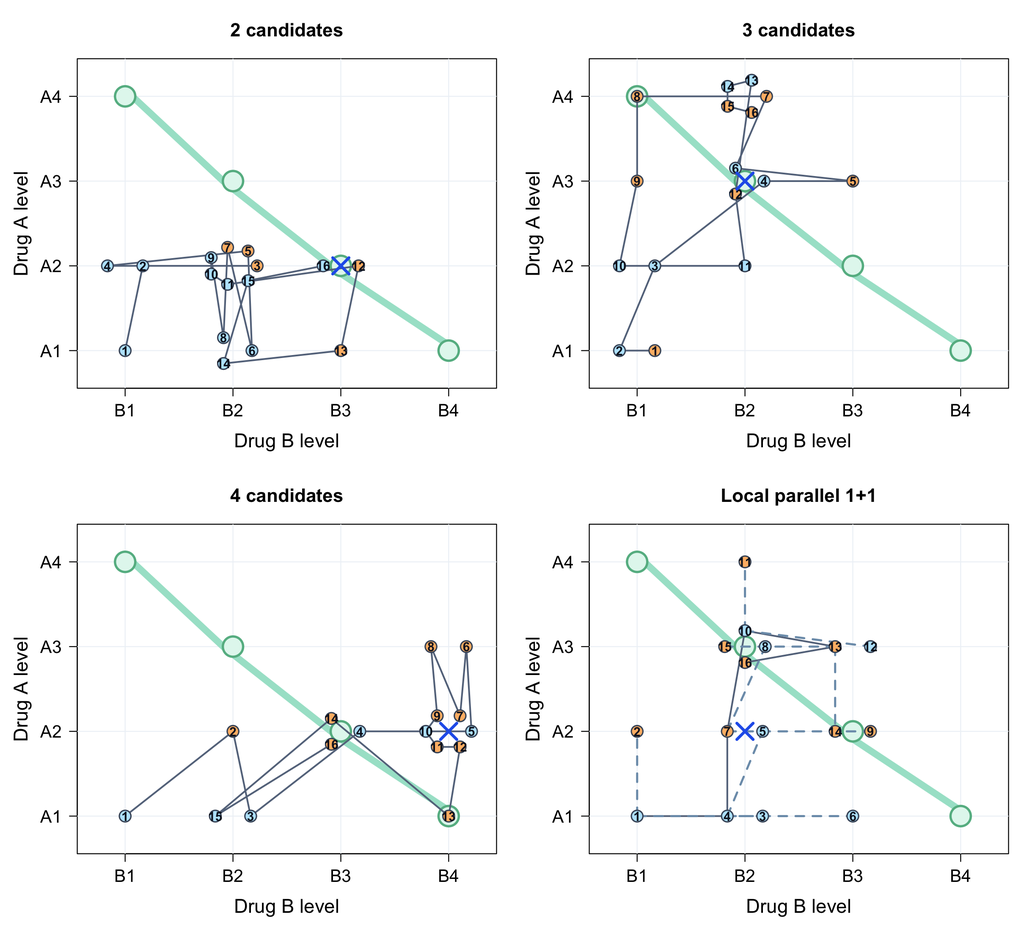

```r
example_trials <- lapply(candidate_sizes, function(size) {
  run_combo_boin_trial(
    scenarios[["Global synergy"]],
    target = target,
    n_patients = n_patients,
    cohort_size = cohort_size,
    candidate_size = size,
    seed = 800 + size
  )
})
example_trials[[4L]] <- run_parallel_combo_boin_trial(
  scenarios[["Global synergy"]],
  target = target,
  n_patients = n_patients,
  cohort_size = cohort_size,
  parallel_cohorts_per_combo = parallel_cohorts_per_combo,
  seed = 804
)
old_par <- par(mfrow = c(2, 2), mar = c(5.0, 5.0, 3.8, 1))
for (i in seq_along(example_trials)) {
  plot_combo_trial_path(
    example_trials[[i]],
    main = example_trials[[i]]$design
  )
}
```

```r
par(old_par)
```

# 6 Performance metrics and formulas

Notation: $R$ is the number of trials, $N_r$ is trial size, $\widehat d_r$ is the selected combination, and $n_r(d)$ is the number treated at combination $d$; $M$, $T$, and $O$ are the true-MTD, clearly-toxic, and above-target sets.

## 6.1 Accuracy

**PCS — larger is better:** the proportion of trials selecting any combination in the true MTD set $M$.

$$\text{PCS}=\frac{1}{R}\sum_{r=1}^R I(\widehat d_r\in M).$$

- A true MTD is a cell closest to $\phi=0.25$; tied cells are all correct.

## 6.2 Safety

**B1 — smaller is better:** the proportion of trials selecting a clearly toxic combination, where $T=\{d:p(d)>0.33\}$.

$$B1=\frac{1}{R}\sum_{r=1}^R I\{p(\widehat d_r)>0.33\}.$$

**B2 — smaller is better:** the mean proportion of patients allocated to clearly toxic combinations.

$$B2=\frac{1}{R}\sum_{r=1}^R
\frac{\sum_{d\in T}n_r(d)}{N_r}.$$

- The threshold is strictly greater than 0.33; a cell at exactly 0.33 is not in $T$.

## 6.3 Reliability

**C1 — smaller is better:** the proportion of trials assigning more than half their patients above target, where $O=\{d:p(d)>\phi\}$.

$$C1=\frac{1}{R}\sum_{r=1}^R
I\left\{\frac{\sum_{d\in O}n_r(d)}{N_r}>0.50\right\}.$$

**C2 — smaller is better:** the proportion of trials treating fewer than six patients at the true MTD set.

$$C2=\frac{1}{R}\sum_{r=1}^R
I\left\{\sum_{d\in M}n_r(d)<6\right\}.$$

**C3 — smaller is better:** among high-toxicity decision opportunities, the proportion not followed by strict de-escalation or a safety stop.

$$C3=\frac{\text{number of qualifying decisions not followed by a strict
coordinate-wise de-escalation or safety stop}}
{\text{number of qualifying decisions}}.$$

- A qualifying opportunity is at least 2/3 DLTs, or more than 3/6 after six or more patients at that cell.
- Local parallel is assessed after the precommitted block, when adaptation is first allowed.
- The C3 event count is printed because a percentage based on few events is unstable.

# 7 Simulation experiment

```r
main_simulation_file <- file.path(
  simulation_data_dir, "combo_boin_main_simulation.RData"
)
main_simulation_settings <- list(
  version = 2L,
  function_hash = function_hash,
  target = target,
  toxic_threshold = toxic_threshold,
  candidate_sizes = candidate_sizes,
  n_sim = n_sim,
  n_patients = n_patients,
  cohort_size = cohort_size,
  parallel_cohorts_per_combo = parallel_cohorts_per_combo,
  simulation_seed = simulation_seed
)
main_objects <- c("simulation_results", "operating_summary")
main_data_loaded <- load_simulation_data(
  main_simulation_file, main_simulation_settings, main_objects
)
if (!main_data_loaded) {
  simulation_results <- simulate_combo_boin_scenarios(
    scenarios = scenarios,
    candidate_sizes = candidate_sizes,
    include_parallel = TRUE,
    parallel_cohorts_per_combo = parallel_cohorts_per_combo,
    target = target,
    toxic_threshold = toxic_threshold,
    n_sim = n_sim,
    n_patients = n_patients,
    cohort_size = cohort_size,
    seed = simulation_seed,
    n_cores = parallel_cores
  )
  operating_summary <- summarize_combo_boin(simulation_results)
  save_simulation_data(
    main_simulation_file, main_simulation_settings, main_objects
  )
}
```

# 8 Visual comparison of operating characteristics

Read these panels as follows:

- High PCS is better.
- Low B1, B2, C1, C2, and C3 is better.
- Color and point shape both identify the true toxicity scenario.
- Each panel uses a range suited to that metric so small differences remain visible. The compact comparison below reports the leading designs.

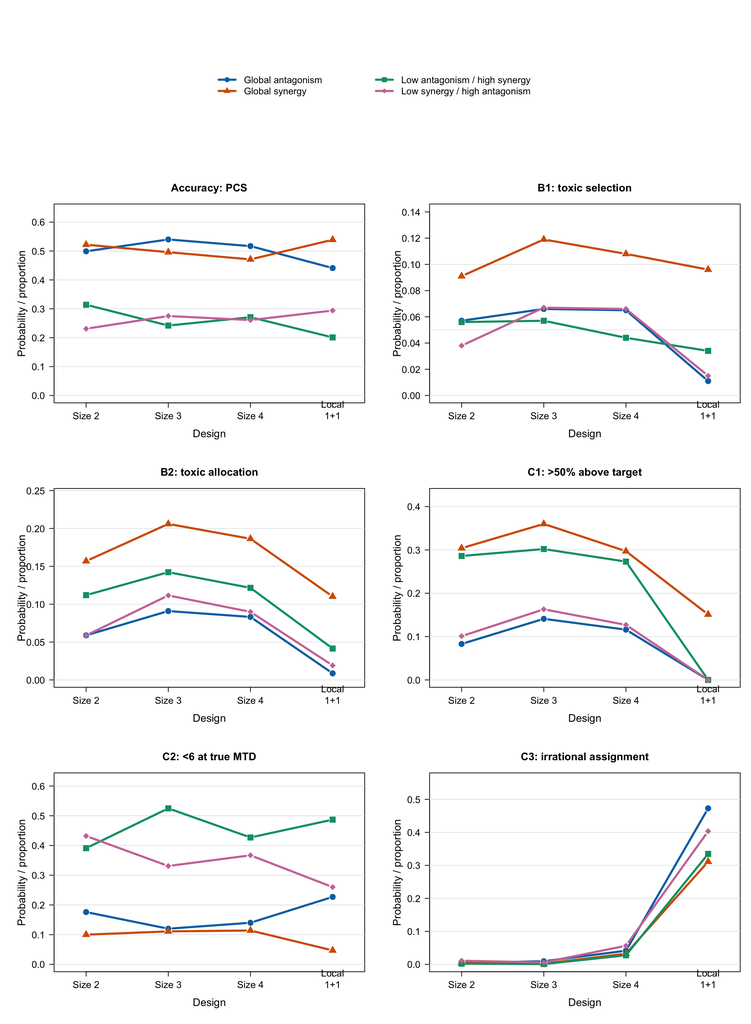

```r
plot_combo_operating_dots(operating_summary)
```

For a quick comparison, the next table identifies which strategy has the largest estimated PCS and which has the lowest clearly-toxic allocation in each scenario. Monte Carlo differences that are only a few percentage points may be noise at this number of replicates.

```r
comparison <- do.call(rbind, lapply(split(
  operating_summary, operating_summary$scenario
), function(x) {
  data.frame(
    scenario = x$scenario[1L],
    highest_PCS_design = x$design[which.max(x$PCS)],
    highest_PCS = max(x$PCS),
    lowest_B2_design = x$design[which.min(x$B2_toxic_allocation)],
    lowest_B2 = min(x$B2_toxic_allocation)
  )
}))
rownames(comparison) <- NULL
knitr::kable(comparison, digits = 3, row.names = FALSE)
```

| scenario | highest_PCS_design | highest_PCS | lowest_B2_design | lowest_B2 |
| --- | --- | --- | --- | --- |
| Global antagonism | 3 candidates | 0.540 | Local parallel 1+1 | 0.009 |
| Global synergy | Local parallel 1+1 | 0.539 | Local parallel 1+1 | 0.110 |
| Low antagonism / high synergy | 2 candidates | 0.314 | Local parallel 1+1 | 0.041 |
| Low synergy / high antagonism | Local parallel 1+1 | 0.294 | Local parallel 1+1 | 0.019 |

# 9 Where the design selects

Each bubble shows a selection probability. Larger bubbles mean more frequent selection, and the value is printed in the bubble. Orange boxes mark true MTDs.

- A diffuse pattern means the design has difficulty learning the MTD contour.
- Frequent selection above the true MTD contour is a safety warning.
- Cells below 0.5% are left blank to reduce visual clutter.

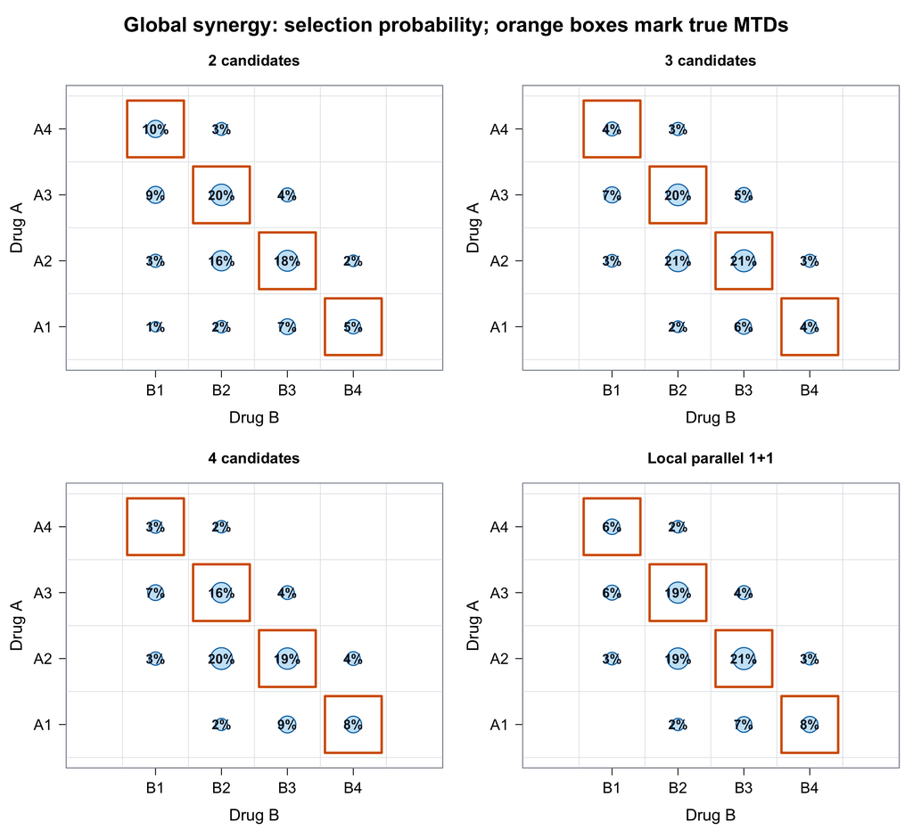

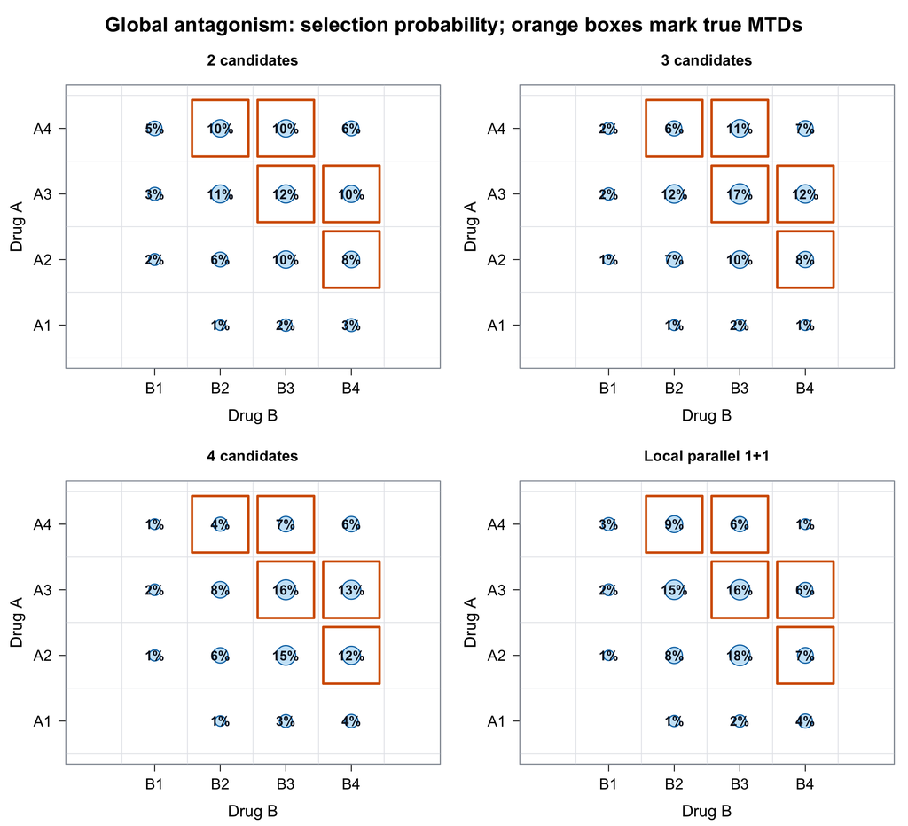

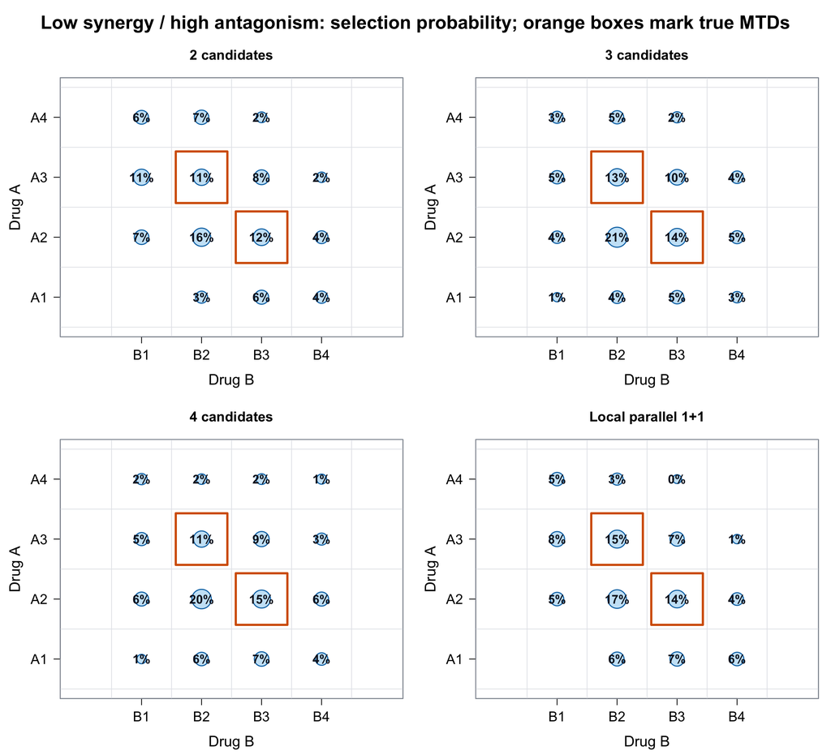

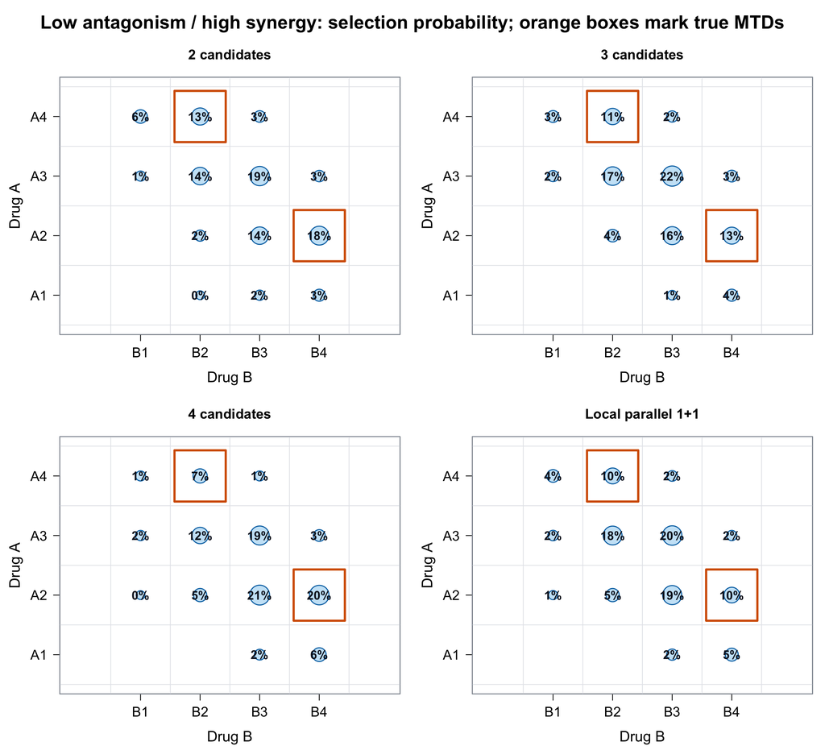

```r
for (name in names(scenarios)) {
  plot_combo_selection_bubbles(
    simulation_results, scenarios, target, scenario_name = name
  )
}
```

# 10 Where patients are treated

Selection and allocation answer different clinical questions:

- Selection describes the final recommendation.
- Allocation describes where trial participants were actually treated.
- A correct final choice does not rule out substantial toxic exposure during escalation.
- Pale yellow cells have true DLT probability above 25% and form the C1 above-target region.
- Pale pink cells have true DLT probability above 33% and form the B2 clearly toxic region.
- C2 is not a grid region; it records trials with fewer than six patients at the true MTD set.
- Cells below 0.5% are left blank to reduce visual clutter.

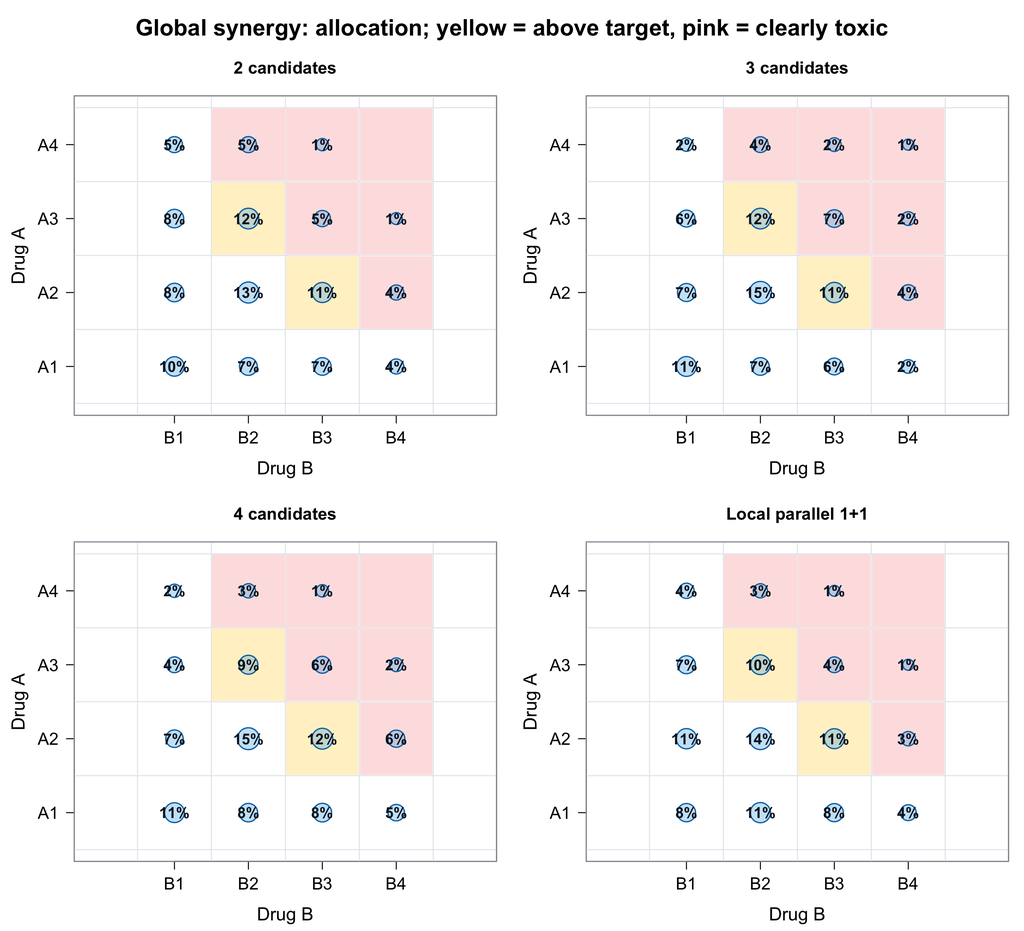

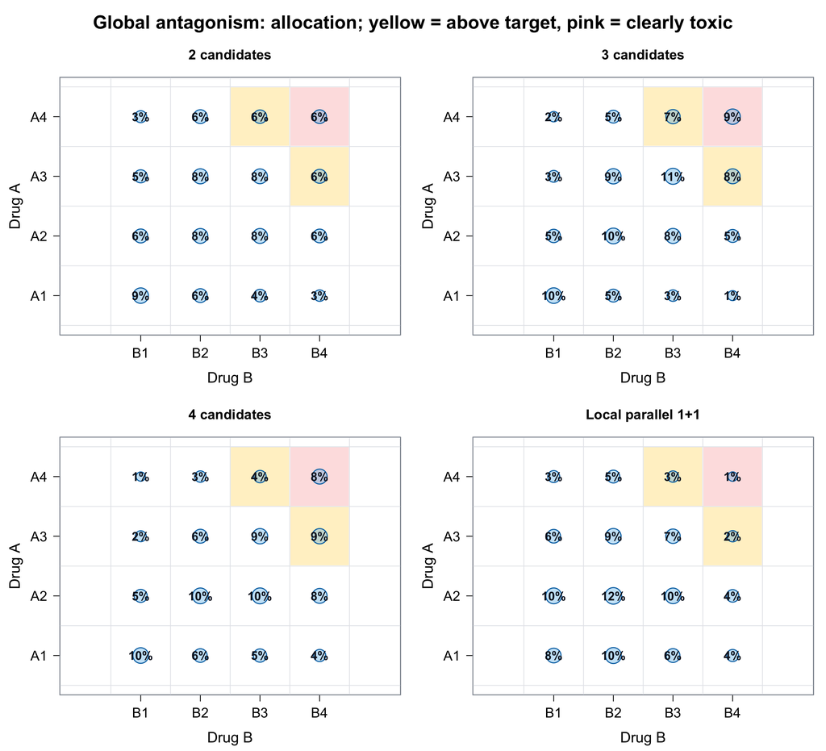

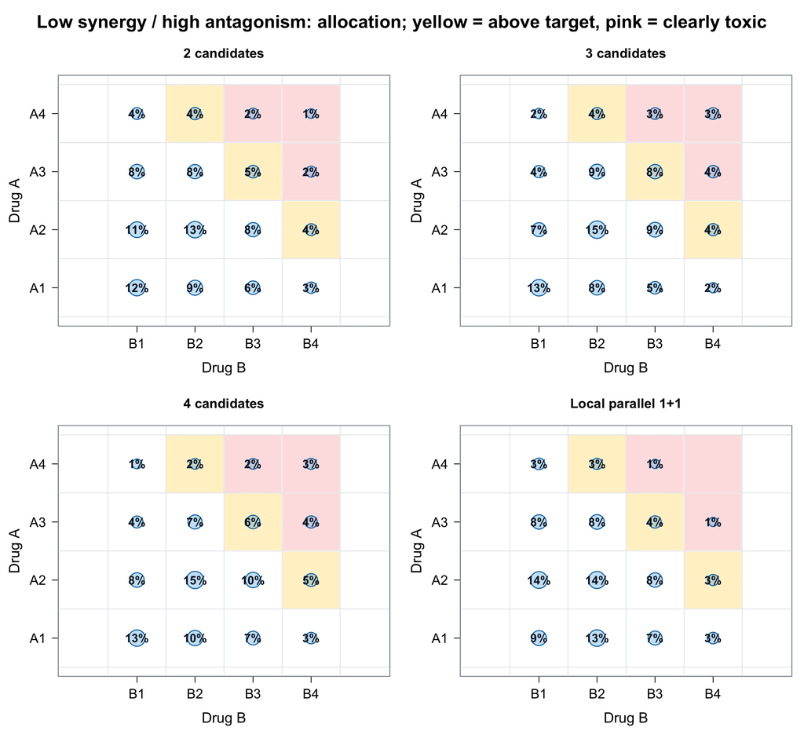

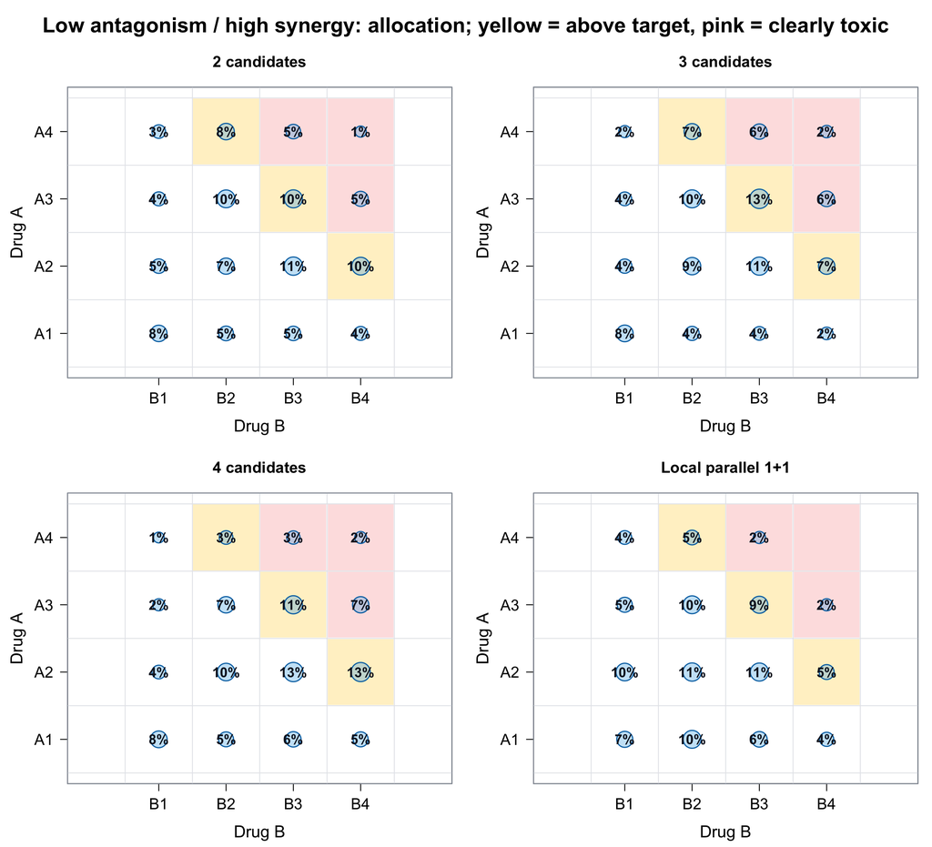

```r
for (name in names(scenarios)) {
  plot_combo_allocation_bubbles(
    simulation_results, scenarios, scenario_name = name,
    target = target, toxic_threshold = toxic_threshold
  )
}
```

# 11 Four-method comparison and interpretation

## 11.1 Overall comparison across the four scenarios

The table gives every scenario equal weight. C3 is different: its overall rate is pooled over all qualifying high-toxicity decision points because C3 is an event-based metric.

| Design | PCS | B1 | B2 | C1 | C2 | C3 | MTD allocation | DLT rate |
| --- | --- | --- | --- | --- | --- | --- | --- | --- |
| 2 candidates | 39.1% | 6.0% | 9.7% | 19.4% | 27.5% | 0.6% | 24.0% | 18.8% |
| 3 candidates | 38.8% | 7.7% | 13.8% | 24.1% | 27.2% | 0.4% | 23.7% | 20.3% |
| 4 candidates | 38.0% | 7.1% | 12.0% | 20.3% | 26.2% | 3.8% | 23.7% | 19.5% |
| Local parallel 1+1 | 36.9% | 3.9% | 4.5% | 3.8% | 25.5% | 37.1% | 19.2% | 16.1% |

## 11.2 Short interpretation

- **Accuracy:** 2 candidates has the highest average PCS (39.1%).
- **Local parallel 1+1:** probing both axes protects against an early wrong-path choice, but commits six patients before adapting. Its average PCS is 36.9% and its average true-MTD allocation is 19.2%.
- **C3:** the parallel rule can move from a toxic branch to its sibling. That sibling is lower in one drug but higher in the other, so it fails the strict coordinate-wise de-escalation definition even when the toxic branch is closed.
- **Safety reading:** a branch is filtered after each parallel block, but both cohorts have already been assigned. Favorable B1/B2/C1 therefore does not remove the within-block safety concern.

## 11.3 Why the last two scenarios have lower PCS

- All four toxicity matrices are coordinate-wise monotone. The last two are better described as **crossover-interaction** scenarios: synergy versus antagonism changes with the dose region.
- Exact PCS is harder in those scenarios because each has only **two** true-MTD cells. Global synergy has four and global antagonism has five, so there are more ways to count a selection as correct in the first two scenarios.
- The changing interaction also bends the target contour. Early information about the better escalation axis may be less useful later, and allocation is spread among several near-target neighbors rather than the two exact MTDs.
- Mean PCS across designs is 50.7% for global synergy and 49.9% for global antagonism, versus 26.5% and 25.7% for the two crossover scenarios.

# 12 Sample-size sensitivity: 48 to 90 patients

This second experiment changes only the maximum sample size. The toxicity scenarios, cohort size, four allocation rules, target, safety threshold, and final MTD-selection rule remain unchanged.

- Maximum sample size increases by two cohorts (6 patients) at each step: 48, 54, 60, 66, 72, 78, 84, 90.
- Each scenario-design-size cell uses 1000 independent trials.
- The full sensitivity study contains 128000 trials.
- Up to 8 base-R workers run different sample sizes in parallel on macOS/Linux. Each sample size has its own fixed seed, so requesting fewer workers does not change the simulated result. Windows falls back to the same calculation sequentially.
- A larger maximum is an opportunity to learn; it does not guarantee a better decision in every Monte Carlo run or at every intermediate value of N.

```r
sample_size_simulation_file <- file.path(
  simulation_data_dir, "combo_boin_sample_size_simulation.RData"
)
sample_size_simulation_settings <- list(
  version = 2L,
  function_hash = function_hash,
  target = target,
  toxic_threshold = toxic_threshold,
  candidate_sizes = candidate_sizes,
  sample_size_grid = sample_size_grid,
  n_sim = n_sim_sample_size,
  cohort_size = cohort_size,
  parallel_cohorts_per_combo = parallel_cohorts_per_combo,
  simulation_seed = simulation_seed + 50000L
)
sample_size_objects <- "sample_size_summary"
sample_size_data_loaded <- load_simulation_data(
  sample_size_simulation_file,
  sample_size_simulation_settings,
  sample_size_objects
)
if (!sample_size_data_loaded) {
  sample_size_summary <- simulate_combo_boin_sample_size_grid(
    scenarios = scenarios,
    sample_sizes = sample_size_grid,
    candidate_sizes = candidate_sizes,
    include_parallel = TRUE,
    parallel_cohorts_per_combo = parallel_cohorts_per_combo,
    target = target,
    toxic_threshold = toxic_threshold,
    n_sim = n_sim_sample_size,
    cohort_size = cohort_size,
    seed = simulation_seed + 50000L,
    n_cores = parallel_cores
  )
  save_simulation_data(
    sample_size_simulation_file,
    sample_size_simulation_settings,
    sample_size_objects
  )
}
```

## 12.1 Performance curves

- Each page holds one true scenario so the four allocation rules remain easy to compare.
- Curves may wiggle because each point is estimated from 1000 trials.
- PCS should be read upward; B1, B2, C1, C2, and C3 should be read downward.
- C2 often benefits directly from extra cohorts because there are more chances to place at least six patients on the true MTD contour.

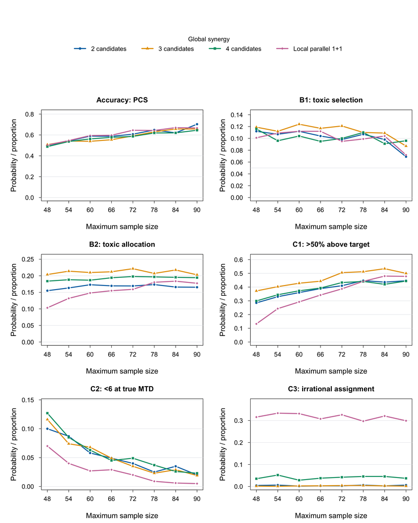

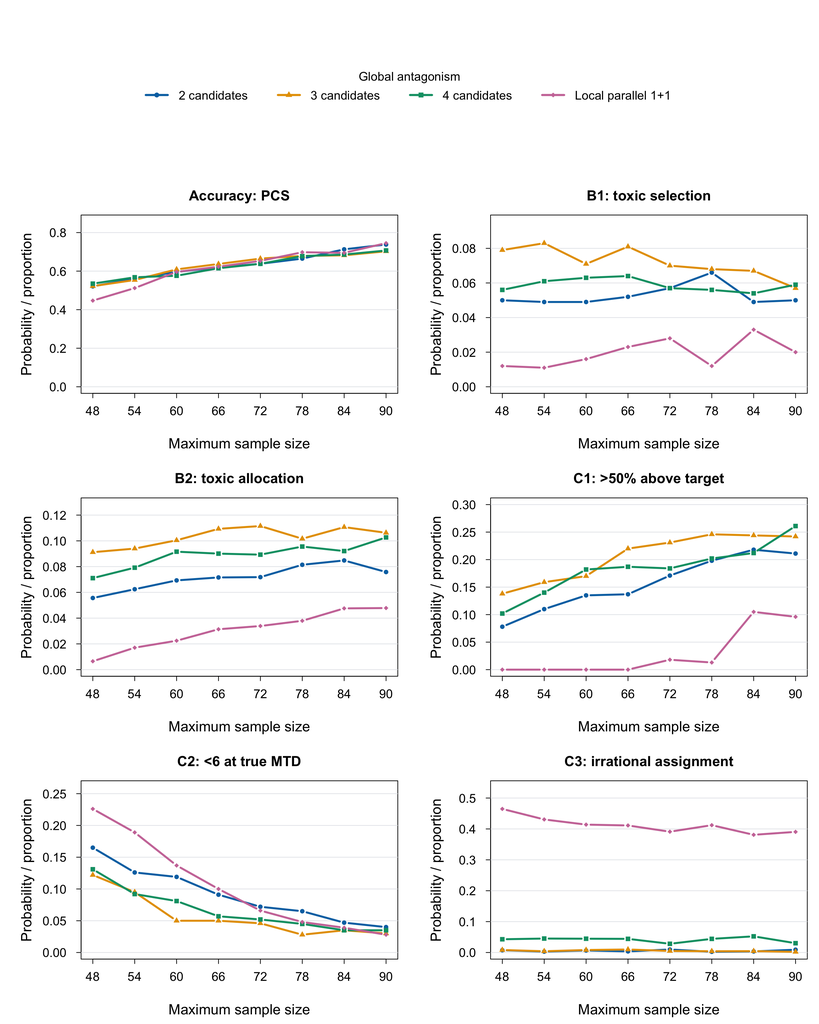

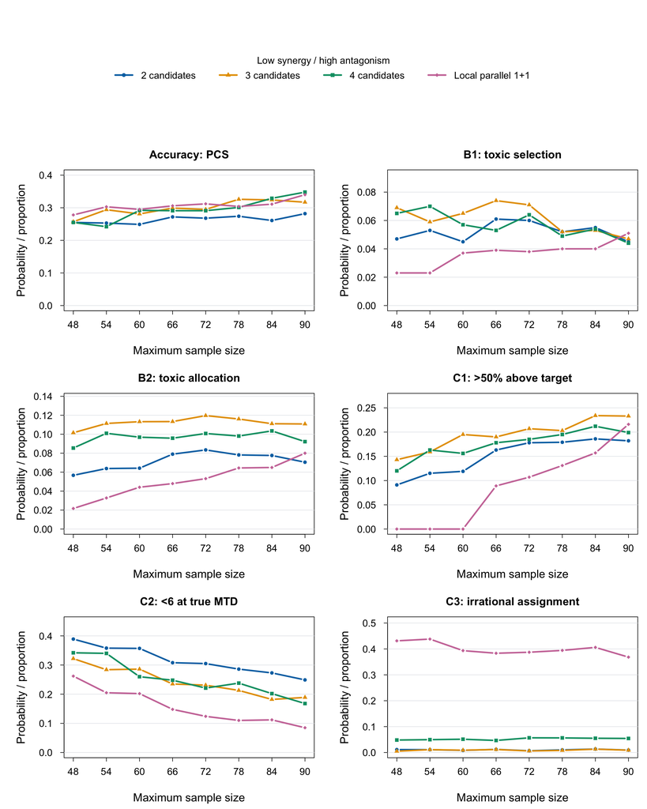

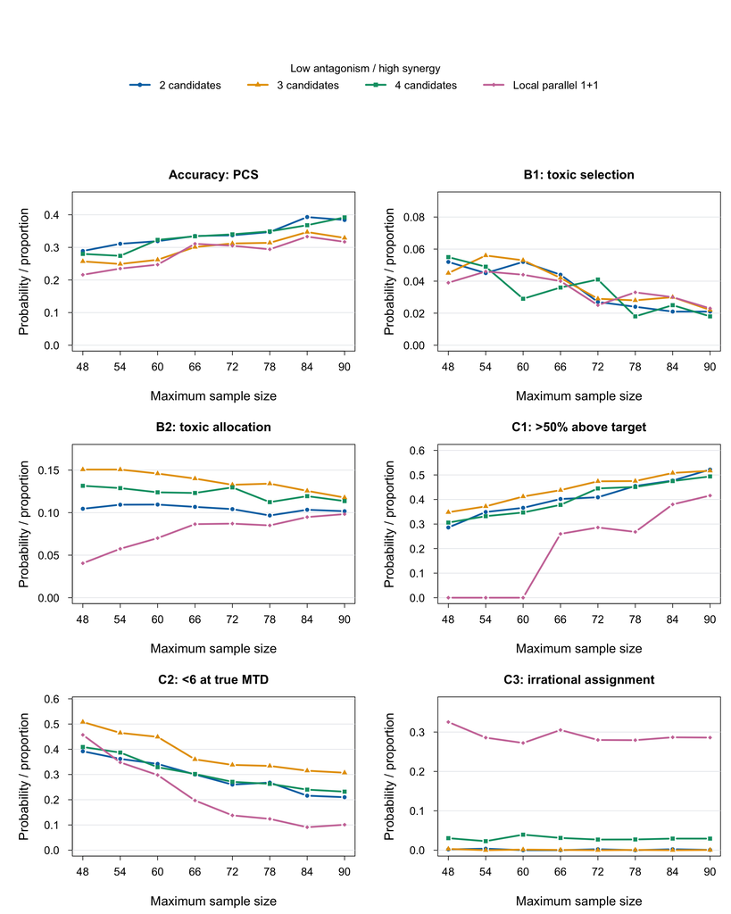

```r
for (name in names(scenarios)) {
  plot_sample_size_metrics(sample_size_summary, name)
}
```

## 12.2 Accuracy-safety paths

The next figure puts efficacy of learning and participant safety on one plane. The preferred direction is **up and left**: higher PCS with less allocation to combinations whose true DLT probability is above 33%. Labels mark the start (`48`) and end (`90`) of each path; the intervening points are the six-patient increments.

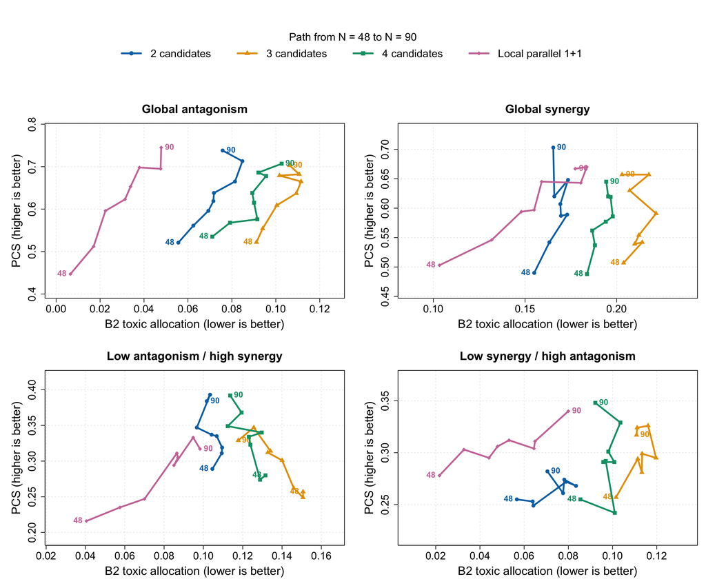

```r
plot_sample_size_tradeoff(sample_size_summary)
```

## 12.3 Conclusions from the sample-size experiment

- **PCS:** It increases from N = 48 to 90 in 16 of 16 scenario-design comparisons; changes range from +2.7 to +29.8 percentage points.
- **C2:** Poor allocation decreases in 16 of 16 comparisons; changes range from -35.6 to -6.5 percentage points.
- **Safety:** B2 decreases in 4 of 16 comparisons, while C1 increases in 16 of 16. C1 can rise when extra patients are assigned to true-MTD cells at 26% to 28% because those cells are still above phi = 25%.
- With 1,000 trials, the largest Monte Carlo standard error for a probability is about 1.6 percentage points.